# COVID-19 Case Study

# Background

The outbreak of the novel Corona virus disease 2019 (COVID-19) was declared a public health emergency of international concern by the World Health Organization (WHO) on January 30, 2020. Upwards of [112 million cases have been confirmed worldwide, with nearly 2.5 million associated deaths](https://covid19.who.int/). Within the US alone, there have been [over 500,000 deaths and upwards of 28 million cases reported](https://covid.cdc.gov/covid-data-tracker/#trends_dailytrendscases). Governments around the world have implemented and suggested a number of policies to lessen the spread of the pandemic, including mask-wearing requirements, travel restrictions, business and school closures, and even stay-at-home orders. The global pandemic has impacted the lives of individuals in countless ways, and though many countries have begun vaccinating individuals, the long-term impact of the virus remains unclear.

The impact of COVID-19 on a given segment of the population appears to vary drastically based on the socioeconomic characteristics of the segment. In particular, differing rates of infection and fatalities have been reported among different [racial groups](https://www.cdc.gov/coronavirus/2019-ncov/covid-data/investigations-discovery/hospitalization-death-by-race-ethnicity.html), [age groups](https://www.cdc.gov/coronavirus/2019-ncov/covid-data/investigations-discovery/hospitalization-death-by-age.html), and [socioeconomic groups](https://www.ncbi.nlm.nih.gov/pmc/articles/PMC7221360/). One of the most important metrics for determining the impact of the pandemic is the death rate, which is the proportion of people within the total population that die due to the the disease.

There are two main goals for this case study.

1. Show the dynamic evolvement of COVID cases and COVID-related death at state level.
2. Try to figure out what county-level demographic and policy interventions are associated with mortality rate in the US. We try to construct models to find possible factors related to county-level COVID-19 mortality rates.

# Data Summary

The data comes from several different sources:

1. [County-level infection and fatality data](https://github.com/nytimes/covid-19-data) - This dataset gives daily cumulative numbers on infection and fatality for each county.
   - [NYC data](https://github.com/nychealth/coronavirus-data)
2. [County-level socioeconomic data](https://www.ers.usda.gov/data-products/atlas-of-rural-and-small-town-america/download-the-data/) - The following are the four relevant datasets from this site.
   1. Income - Poverty level and household income.
   2. Jobs - Employment type, rate, and change.
   3. People - Population size, density, education level, race, age, household size, and migration rates.
   4. County Classifications - Type of county (rural or urban on a rural-urban continuum scale).
3. [Intervention Policy Data](https://github.com/JieYingWu/COVID-19_US_County-level_Summaries/blob/master/data/interventions.csv) - This dataset is a manually compiled list of the dates that interventions/lockdown policies were implemented and lifted at the county level.

# EDA

First read in the data.

```r
# county-level socialeconomic information
county_data <- fread("data/covid_county.csv")
# county-level COVID case and death
covid_rate <- fread("data/covid_rates.csv")
# county-level lockdown dates
# covid_intervention <- fread("data/covid_intervention.csv")
```

```r
# county-level COVID case and death
#covid_rate <- fread("covid_rates.csv")
```

county_data breaks down various demographic and socioeconomic variables by U.S. county. Each county is uniquely identified by FIPS variable, which identifies the U.S state or territory and county of a given county. States are indicated by the first one or two digits (1 for AL, 2 for AK, …, 72 for PR) followed by numbers which indicate the county within that state.

Covid_rate breaks down the daily number of COVID cases and deaths of each county (uniquely identified by FIPS). The observations span from January 2020 to February 2021.

## COVID case trend

It is crucial to decide the right granularity for visualization and analysis. We will compare daily vs weekly total new cases by state and we will see it is hard to interpret daily report.

The biggest problem is the volatility in number of new cases per day. It can be difficult to analyze trend when the y variable rises and falls frequently.

```r
num_rows <- nrow(covid_rate)
cum_cases <- covid_rate$cum_cases
FIPS <- covid_rate$FIPS
new_cases <-c(rep(NA,num_rows))

for(i in 2:num_rows){
  new_case <- cum_cases[i] - cum_cases[i-1]
  if (FIPS[i] == FIPS[i-1]) {
    new_cases[i]<- new_case
  } else {
    new_cases[i]<- cum_cases[i]
  }
}

covid_rate$new_cases <- new_cases
```

```r
covid_rate_NY <- covid_rate %>% filter(State == "New York") %>% group_by(date) %>% summarize(new_cases = sum(new_cases))

covid_rate_NY$Day <-  seq(1, nrow(covid_rate_NY))
```

```r
covid_rate_WA <- covid_rate %>% filter(State == "Washington") %>% group_by(date) %>% summarize(new_cases = sum(new_cases))

covid_rate_WA$Day <-  seq(1, nrow(covid_rate_WA))
```

```r
covid_rate_FL <- covid_rate %>% filter(State == "Florida") %>% group_by(date) %>% summarize(new_cases = sum(new_cases))

covid_rate_FL$Day <-  seq(1, nrow(covid_rate_FL))
```

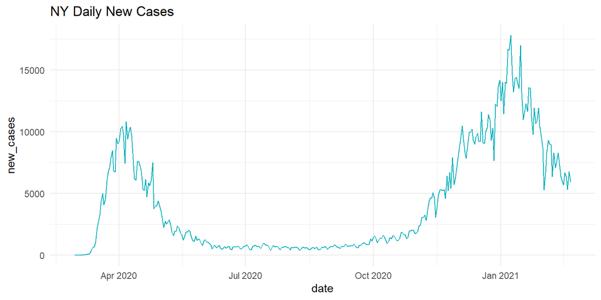

```r
ggplot(data=covid_rate_NY, aes(date, new_cases)) +
theme_minimal() +
geom_line(color = "#00AFBB", size = .4) +
labs(title = "NY Daily New Cases")
```

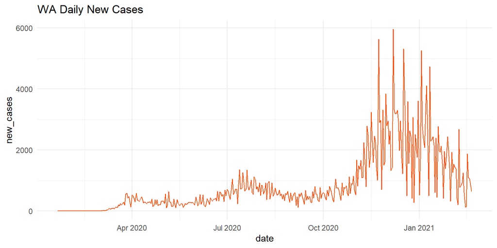

```r
ggplot(data=covid_rate_WA, aes(date, new_cases)) +
theme_minimal() +
geom_line(color = "#FC4E07", size = .4) +
labs(title = "WA Daily New Cases")
```

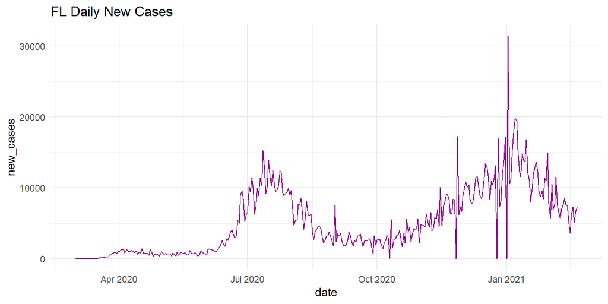

```r
ggplot(data=covid_rate_FL, aes(date, new_cases)) +
theme_minimal() +
geom_line(color = "darkmagenta", size = .4) +
labs(title = "FL Daily New Cases")
```

```r
state_pop <- covid_rate %>% group_by(State, County) %>% summarize(county_pop = mean(TotalPopEst2019)) %>% group_by(State) %>% summarize(state_pop = sum(county_pop))
covid_rate_week <- covid_rate %>% group_by(State, week) %>% summarize(weekly_new_cases = sum(new_cases))
covid_rate_week <- merge(x=covid_rate_week,y=state_pop,by="State",all.x=TRUE)
```

```r
covid_rate_week <- covid_rate_week %>% mutate(weekly_case_per100k = (weekly_new_cases/(state_pop) * 100000))
```

```r
covid_wk_rate_NY <- covid_rate_week %>% filter(State == "New York")
covid_wk_rate_WA <- covid_rate_week %>% filter(State == "Washington")
covid_wk_rate_FL <- covid_rate_week %>% filter(State == "Florida")
```

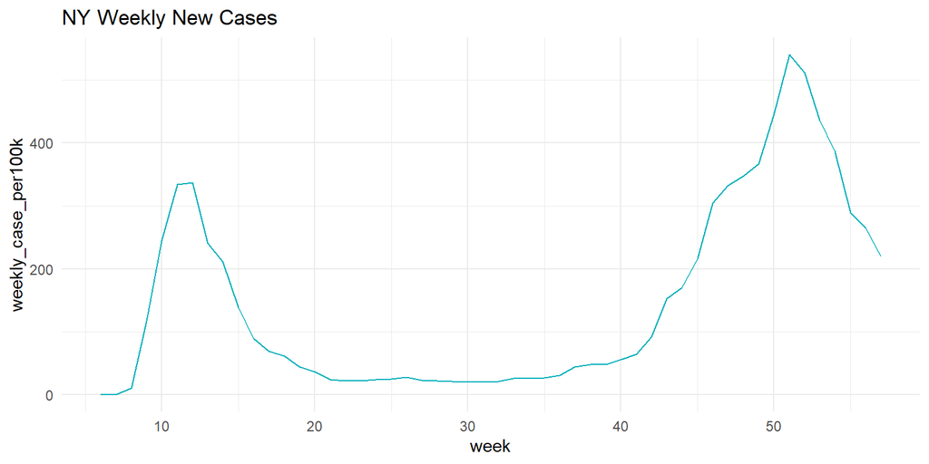

```r
ggplot(data=covid_wk_rate_NY, aes(week, weekly_case_per100k)) +
theme_minimal() +
geom_line(color = "#00AFBB", size = .4) +
labs(title = "NY Weekly New Cases")
```

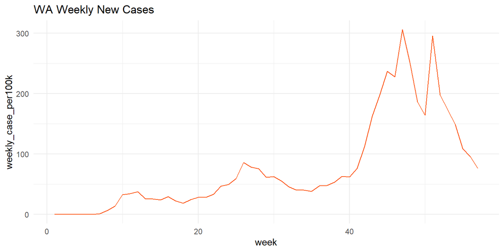

```r
ggplot(data=covid_wk_rate_WA, aes(week, weekly_case_per100k)) +
theme_minimal() +
geom_line(color = "#FC4E07", size = .4) +
labs(title = "WA Weekly New Cases")
```

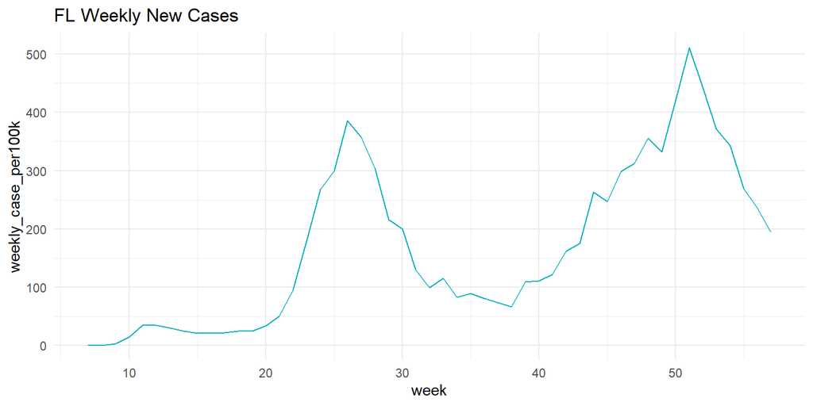

```r
ggplot(data=covid_wk_rate_FL, aes(week, weekly_case_per100k)) +
theme_minimal() +
geom_line(color = "#00AFBB", size = .4) +
labs(title = "FL Weekly New Cases")
```

## COVID death trend

```r
# create a month index
month <- substr(unique(covid_rate$date), 1, 7)
unique_months <- unique(month)

month_index <- arrange_all(data.frame(unique_months))
index_len <- nrow(month_index)
month_index <- month_index %>% mutate(month = c(1:index_len))
```

```r
# create new column to serve as basis of join
covid_rate <- covid_rate %>% mutate (unique_months = (substr(date, 1, 7)))
```

```r
# merge the month index
covid_rate <- merge(x=covid_rate,y=month_index,by="unique_months",all.x=TRUE)
```

```r
covid_rate_month <- covid_rate %>% group_by(State, month) %>% summarize(weekly_new_cases = sum(new_cases))
# compute "new deaths" as we did "new cases" previously
num_rows <- nrow(covid_rate)
cum_deaths <- covid_rate$cum_deaths
FIPS <- covid_rate$FIPS
new_deaths <-c(rep(NA,num_rows))

for(i in 2:num_rows){
  new_death <- cum_deaths[i] - cum_deaths[i-1]
  if (FIPS[i] == FIPS[i-1]) {
    new_deaths[i]<- new_death
  } else {
    new_deaths[i]<- cum_deaths[i]
  }
}

covid_rate$new_deaths <- new_deaths
```

```r
# compute monthly state deaths
covid_state_deaths <- covid_rate %>% group_by(State, month) %>% summarize(monthly_new_deaths = sum(new_deaths))
# merge the state populations column
covid_state_deaths <- merge(x= covid_state_deaths, y= state_pop, on="State", all.x=TRUE)
```

```r
# compute deaths per 100k
covid_state_deaths <- covid_state_deaths %>% mutate(monthly_deaths_per100k = (monthly_new_deaths/(state_pop) * 100000))
```

```r
# create df for our heatmap

# months 1-12 represent Jan 2020- Dec 2020
heatmap_df <- covid_state_deaths %>% select(State, month, monthly_deaths_per100k) %>% filter(month <= 12)
```

```r
# create df for our heatmap

# months 1-12 represent Jan 2020- Dec 2020
heatmap_df <- covid_state_deaths %>% select(State, month, monthly_deaths_per100k) %>% filter(month <= 12)
```

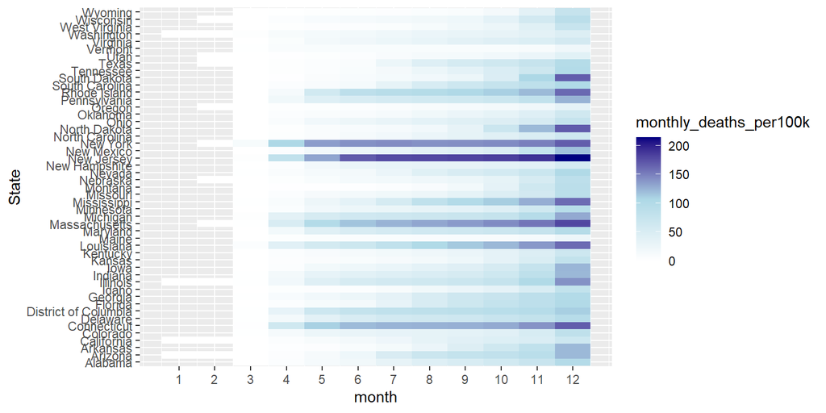

```r
# heatmap
ggplot(heatmap_df, aes(month, State, fill= monthly_deaths_per100k)) +
  geom_tile() +
  scale_fill_gradientn(colours = c("white", "lightblue", "navy"), na.value = "white") +
  scale_x_continuous(breaks=1:12)
```

# COVID factor

We now try to build a good parsimonious model to find possible factors related to death rate on county level. Let us not take time series into account for the moment and use the total number as of *Feb 1, 2021*.

```r
feb1 <- covid_rate %>% filter(date == "2021-02-01")
feb1 <- feb1 %>% mutate(total_death_per100k = (cum_deaths/TotalPopEst2019)*100000)
feb1 <- feb1 %>% mutate(log_total_death_per100k = log(total_death_per100k + 1))
feb1 <- feb1 %>% select(FIPS, total_death_per100k, log_total_death_per100k)
```

```r
# merge
county_data <- merge(x=county_data, y=feb1, on="FIPS", all.x=TRUE)
# added MedHHInc, PerCapitaInc, and PopDensity2010 as possible covariates
# added response variable total_death_per100k at the end

sel_vars <- county_data %>%
  select(County, State, FIPS, MedHHInc, PerCapitaInc, Deep_Pov_All, PovertyAllAgesPct, PerCapitaInc, UnempRate2019, PctEmpFIRE, PctEmpConstruction, PctEmpTrans, PctEmpMining, PctEmpTrade, PctEmpInformation, PctEmpAgriculture, PctEmpManufacturing, PctEmpServices, PopDensity2010, OwnHomePct, Age65AndOlderPct2010, TotalPop25Plus, Under18Pct2010, Ed2HSDiplomaOnlyPct, Ed3SomeCollegePct, Ed4AssocDegreePct, Ed5CollegePlusPct, ForeignBornPct, Net_International_Migration_Rate_2010_2019, NetMigrationRate1019, NaturalChangeRate1019, TotalPopEst2019, WhiteNonHispanicPct2010, NativeAmericanNonHispanicPct2010, BlackNonHispanicPct2010, AsianNonHispanicPct2010, HispanicPct2010, Type_2015_Update, RuralUrbanContinuumCode2013, UrbanInfluenceCode2013, Perpov_1980_0711, HiCreativeClass2000, HiAmenity, Retirement_Destination_2015_Update, total_death_per100k)
```

```r
# ignoring rows with missing values
sel_vars <- sel_vars[complete.cases(sel_vars), ]
```

We want to force in state as our goal is to analyze COVID-related death rates at state level.

```r
Y <- sel_vars$total_death_per100k
X <- model.matrix(total_death_per100k~., data=sel_vars)[, -1]
#colnames(X) dim(X) dim(sel_vars$total_death_per100k)
```

```r
# create index needed to force in state vars
colx <- colnames(X)
state_index <- c(rep(1, length(colx)))

# we mark State variables with 0s and other variables with 1s
for (i in 1:length(colx)) {
  if (startsWith(colx[i], "State")) {
    state_index[i] <- 0
  }
}

#check sum(state_index) length(colnames(X))
```

```r
# force in state. We use state
set.seed(10)
fit.force.cv <- cv.glmnet(X, Y, alpha=1, nfolds=10, intercept = T,
                       penalty.factor = state_index)

#summary(fit.cv) names(fit.cv)
```

```r
#fit.cv$lambda.1se
coef.1se <- coef(fit.force.cv, s="lambda.1se")
coef.1se <- coef.1se[which(coef.1se !=0),]
coef.1se
```

```
##             (Intercept)           CountyEmporia             CountyGalax
##                1.70e+02                4.58e+01                6.42e+01
##              CountyGove           CountyJerauld                 StateAR
##                2.80e+02                9.98e+01               -5.47e+00
##                 StateAZ                 StateCA                 StateCO
##                5.33e+01               -1.02e+02               -6.00e+01
##                 StateCT                 StateDC                 StateDE
##                4.69e+00               -2.04e+00               -4.03e+01
##                 StateFL                 StateGA                 StateIA
##               -2.72e+01                7.79e+00                1.65e+01
##                 StateID                 StateIL                 StateIN
##               -8.25e+01                7.57e+00               -2.73e+01
##                 StateKS                 StateKY                 StateLA
##               -5.01e+01               -8.93e+01                3.26e+01
##                 StateMA                 StateMD                 StateME
##                1.83e+01               -4.88e+01               -1.40e+02
##                 StateMI                 StateMN                 StateMO
##               -4.32e+01               -5.89e+01               -7.51e+01
##                 StateMS                 StateMT                 StateNC
##                5.00e+01               -9.99e+00               -6.94e+01
##                 StateND                 StateNE                 StateNH
##                6.03e+01               -6.42e+01               -1.00e+02
##                 StateNJ                 StateNM                 StateNV
##                5.65e+01               -2.96e+01               -7.63e+01
##                 StateNY                 StateOH                 StateOK
##               -5.89e+01               -7.15e+01               -8.64e+01
##                 StateOR                 StatePA                 StateRI
##               -1.21e+02               -6.25e+00               -1.34e+01
##                 StateSC                 StateSD                 StateTN
##               -6.06e+00                8.13e+01               -3.39e+00
##                 StateTX                 StateUT                 StateVA
##                2.53e+01               -1.07e+02               -7.27e+01
##                 StateVT                 StateWA                 StateWI
##               -1.50e+02               -1.10e+02               -5.17e+01
##                 StateWV                 StateWY                MedHHInc
##               -9.10e+01               -6.87e+01               -5.47e-05
##       PovertyAllAgesPct      PctEmpConstruction    Age65AndOlderPct2010
##                9.83e-01               -4.54e-01                1.53e+00
##       Ed5CollegePlusPct    NetMigrationRate1019 WhiteNonHispanicPct2010
##               -8.71e-01               -1.57e+00               -6.66e-03
```

```r
var.1se <- rownames(as.matrix(coef.1se))[-1]

lm.input <- as.formula(paste("total_death_per100k", "~", paste(var.1se, collapse = "+")))
# prepare for lm fomulae
lm.input
```

```
## total_death_per100k ~ CountyEmporia + CountyGalax + CountyGove +
##     CountyJerauld + StateAR + StateAZ + StateCA + StateCO + StateCT +
##     StateDC + StateDE + StateFL + StateGA + StateIA + StateID +
##     StateIL + StateIN + StateKS + StateKY + StateLA + StateMA +
##     StateMD + StateME + StateMI + StateMN + StateMO + StateMS +
##     StateMT + StateNC + StateND + StateNE + StateNH + StateNJ +
##     StateNM + StateNV + StateNY + StateOH + StateOK + StateOR +
##     StatePA + StateRI + StateSC + StateSD + StateTN + StateTX +
##     StateUT + StateVA + StateVT + StateWA + StateWI + StateWV +
##     StateWY + MedHHInc + PovertyAllAgesPct + PctEmpConstruction +
##     Age65AndOlderPct2010 + Ed5CollegePlusPct + NetMigrationRate1019 +
##     WhiteNonHispanicPct2010
```

```r
# one hot encode selected data subset
sel_vars$County <- as.factor(sel_vars$County)
sel_vars$State <- as.factor(sel_vars$State)
sel_vars1 <- one_hot(sel_vars)

# remove underscore from column names
names(sel_vars1)<-gsub("\\_","",names(sel_vars1))
sel_vars1 <- rename(sel_vars1, total_death_per100k = totaldeathper100k)

# colnames(sel_vars1) sel_vars1$totaldeathper100k sel_vars1$total_death_per100k
```

```r
fit.1se.lm <- lm(lm.input, data=sel_vars1)
summary(fit.1se.lm)
```

```
##
## Call:
## lm(formula = lm.input, data = sel_vars1)
##
## Residuals:
##    Min     1Q Median     3Q    Max
## -298.3  -44.8   -6.1   34.6  513.5
##
## Coefficients:
##                          Estimate Std. Error t value Pr(>|t|)
## (Intercept)              1.81e+02   2.68e+01    6.74  1.9e-11 ***
## CountyEmporia            4.16e+02   7.79e+01    5.34  1.0e-07 ***
## CountyGalax              4.64e+02   7.77e+01    5.97  2.7e-09 ***
## CountyGove               6.85e+02   7.78e+01    8.81  < 2e-16 ***
## CountyJerauld            4.98e+02   7.80e+01    6.38  2.1e-10 ***
## StateAR                 -1.55e+00   1.31e+01   -0.12  0.90570
## StateAZ                  3.60e+01   2.23e+01    1.62  0.10632
## StateCA                 -1.08e+02   1.43e+01   -7.57  4.9e-14 ***
## StateCO                 -3.19e+01   1.39e+01   -2.29  0.02226 *
## StateCT                  1.90e+01   2.94e+01    0.65  0.51877
## StateDC                 -1.29e+01   7.84e+01   -0.16  0.86969
## StateDE                 -3.44e+01   4.58e+01   -0.75  0.45241
## StateFL                 -2.64e+01   1.37e+01   -1.93  0.05354 .
## StateGA                  1.29e+01   1.13e+01    1.14  0.25458
## StateIA                  2.92e+01   1.28e+01    2.28  0.02249 *
## StateID                 -5.92e+01   1.52e+01   -3.89  0.00010 ***
## StateIL                  1.85e+01   1.27e+01    1.46  0.14433
## StateIN                 -4.66e+00   1.29e+01   -0.36  0.71759
## StateKS                 -4.46e+01   1.26e+01   -3.55  0.00039 ***
## StateKY                 -6.37e+01   1.23e+01   -5.18  2.4e-07 ***
## StateLA                  3.91e+01   1.36e+01    2.87  0.00411 **
## StateMA                  4.20e+01   2.33e+01    1.81  0.07110 .
## StateMD                 -4.04e+01   1.89e+01   -2.14  0.03265 *
## StateME                 -1.10e+02   2.18e+01   -5.05  4.6e-07 ***
## StateMI                 -2.95e+01   1.30e+01   -2.27  0.02301 *
## StateMN                 -4.23e+01   1.31e+01   -3.24  0.00120 **
## StateMO                 -5.49e+01   1.22e+01   -4.51  6.8e-06 ***
## StateMS                  4.50e+01   1.28e+01    3.52  0.00044 ***
## StateMT                  7.34e+00   1.43e+01    0.51  0.60675
## StateNC                 -6.28e+01   1.23e+01   -5.11  3.4e-07 ***
```

[output cut: 21 more lines]

```
## StateWV                 -7.03e+01   1.45e+01   -4.87  1.2e-06 ***
## StateWY                 -4.16e+01   1.90e+01   -2.18  0.02901 *
## MedHHInc                 5.55e-04   2.58e-04    2.15  0.03177 *
## PovertyAllAgesPct        1.33e+00   5.09e-01    2.62  0.00886 **
## PctEmpConstruction      -3.82e+00   6.63e-01   -5.76  9.4e-09 ***
## Age65AndOlderPct2010     5.37e+00   4.74e-01   11.34  < 2e-16 ***
## Ed5CollegePlusPct       -1.83e+00   2.44e-01   -7.49  9.3e-14 ***
## NetMigrationRate1019    -1.85e+00   2.42e-01   -7.65  2.7e-14 ***
## WhiteNonHispanicPct2010 -9.50e-01   1.28e-01   -7.42  1.5e-13 ***
## ---
## Signif. codes:  0 '***' 0.001 '**' 0.01 '*' 0.05 '.' 0.1 ' ' 1
##
## Residual standard error: 77.4 on 3045 degrees of freedom
## Multiple R-squared:  0.43,   Adjusted R-squared:  0.419
## F-statistic:   39 on 59 and 3045 DF,  p-value: <2e-16
```

```r
data.sub <-  sel_vars1 %>% select(var.1se, "total_death_per100k")
# let's do some column reordering which will help using force.in later while using regsubsets

coln <- colnames(data.sub)
state_vars <- c()
nonstate_vars <- c()
for (i in 1:length(coln)) {
  if (startsWith(coln[i], "State")) {
    state_vars <- c(state_vars, coln[i])
  } else {
    nonstate_vars <- c(nonstate_vars, coln[i])
  }
}

reordered_cols <- c(state_vars, nonstate_vars)
data.sub <- data.sub %>% select(reordered_cols)
fit.1 <- regsubsets(total_death_per100k~., nvmax = 60, method = "exhau", force.in = c(1:48), really.big=TRUE, data.sub)

summary(fit.1)
```

```
## Subset selection object
## Call: regsubsets.formula(total_death_per100k ~ ., nvmax = 60, method = "exhau",
##     force.in = c(1:48), really.big = TRUE, data.sub)
## 59 Variables  (and intercept)
##                         Forced in Forced out
## StateAR                      TRUE      FALSE
## StateAZ                      TRUE      FALSE
## StateCA                      TRUE      FALSE
## StateCO                      TRUE      FALSE
## StateCT                      TRUE      FALSE
## StateDC                      TRUE      FALSE
## StateDE                      TRUE      FALSE
## StateFL                      TRUE      FALSE
## StateGA                      TRUE      FALSE
## StateIA                      TRUE      FALSE
## StateID                      TRUE      FALSE
## StateIL                      TRUE      FALSE
## StateIN                      TRUE      FALSE
## StateKS                      TRUE      FALSE
## StateKY                      TRUE      FALSE
## StateLA                      TRUE      FALSE
## StateMA                      TRUE      FALSE
## StateMD                      TRUE      FALSE
## StateME                      TRUE      FALSE
## StateMI                      TRUE      FALSE
## StateMN                      TRUE      FALSE
## StateMO                      TRUE      FALSE
## StateMS                      TRUE      FALSE
## StateMT                      TRUE      FALSE
## StateNC                      TRUE      FALSE
## StateND                      TRUE      FALSE
## StateNE                      TRUE      FALSE
## StateNH                      TRUE      FALSE
## StateNJ                      TRUE      FALSE
## StateNM                      TRUE      FALSE
## StateNV                      TRUE      FALSE
## StateNY                      TRUE      FALSE
## StateOH                      TRUE      FALSE
## StateOK                      TRUE      FALSE
## StateOR                      TRUE      FALSE
```

[output cut: 119 more lines]

```
## 57  ( 1 ) " "               "*"                "*"
## 58  ( 1 ) "*"               "*"                "*"
## 59  ( 1 ) "*"               "*"                "*"
##           Ed5CollegePlusPct NetMigrationRate1019 WhiteNonHispanicPct2010
## 49  ( 1 ) " "               " "                  " "
## 50  ( 1 ) " "               "*"                  " "
## 51  ( 1 ) " "               "*"                  "*"
## 52  ( 1 ) " "               "*"                  "*"
## 53  ( 1 ) "*"               "*"                  "*"
## 54  ( 1 ) "*"               "*"                  "*"
## 55  ( 1 ) "*"               "*"                  "*"
## 56  ( 1 ) "*"               "*"                  "*"
## 57  ( 1 ) "*"               "*"                  "*"
## 58  ( 1 ) "*"               "*"                  "*"
## 59  ( 1 ) "*"               "*"                  "*"
```

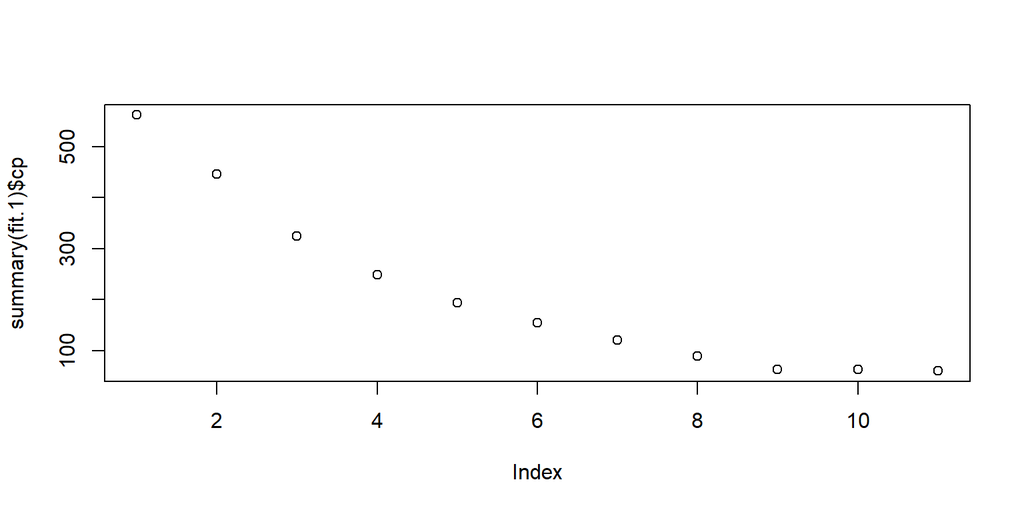

```r
plot(summary(fit.1)$cp)
```

```r
# choosing size 9 by elbow rule
opt.size <- 9

fit.1.s <- summary(fit.1)

var.1 <- fit.1.s$which
final.var <- colnames(var.1)[var.1[opt.size, ]][-1]
```

```r
final_data <- sel_vars1 %>% select(final.var, total_death_per100k)
# final fit
final.fit <- lm(total_death_per100k~., final_data)
summary(final.fit)
```

```
##
## Call:
## lm(formula = total_death_per100k ~ ., data = final_data)
##
## Residuals:
##    Min     1Q Median     3Q    Max
## -298.8  -44.5   -6.1   34.8  513.8
##
## Coefficients:
##                         Estimate Std. Error t value Pr(>|t|)
## (Intercept)              241.783     13.698   17.65  < 2e-16 ***
## StateAR                   -1.195     13.076   -0.09  0.92720
## StateAZ                   36.264     22.254    1.63  0.10330
## StateCA                 -106.352     14.014   -7.59  4.3e-14 ***
## StateCO                  -33.430     13.927   -2.40  0.01643 *
## StateCT                   21.838     29.237    0.75  0.45515
## StateDC                   -7.470     78.403   -0.10  0.92410
## StateDE                  -35.737     45.773   -0.78  0.43501
## StateFL                  -26.729     13.676   -1.95  0.05074 .
## StateGA                   13.720     11.315    1.21  0.22539
## StateIA                   27.940     12.623    2.21  0.02694 *
## StateID                  -62.320     15.163   -4.11  4.1e-05 ***
## StateIL                   18.472     12.549    1.47  0.14113
## StateIN                   -5.817     12.815   -0.45  0.64992
## StateKS                  -47.434     12.468   -3.80  0.00014 ***
## StateKY                  -60.163     12.225   -4.92  9.1e-07 ***
## StateLA                   41.072     13.605    3.02  0.00256 **
## StateMA                   44.169     23.184    1.91  0.05686 .
## StateMD                  -37.846     18.611   -2.03  0.04209 *
## StateME                 -112.399     21.808   -5.15  2.7e-07 ***
## StateMI                  -30.500     12.965   -2.35  0.01871 *
## StateMN                  -43.428     12.891   -3.37  0.00076 ***
## StateMO                  -55.557     12.197   -4.55  5.4e-06 ***
## StateMS                   45.347     12.804    3.54  0.00040 ***
## StateMT                    5.600     14.248    0.39  0.69431
## StateNC                  -64.991     12.275   -5.29  1.3e-07 ***
## StateND                   65.066     14.511    4.48  7.6e-06 ***
## StateNE                  -58.423     12.794   -4.57  5.2e-06 ***
## StateNH                  -68.018     26.546   -2.56  0.01045 *
## StateNJ                   59.719     19.703    3.03  0.00246 **
```

[output cut: 19 more lines]

```
## CountyEmporia            409.285     77.901    5.25  1.6e-07 ***
## CountyGalax              465.560     77.786    5.99  2.4e-09 ***
## CountyGove               685.247     77.854    8.80  < 2e-16 ***
## CountyJerauld            497.625     78.097    6.37  2.1e-10 ***
## PctEmpConstruction        -3.843      0.657   -5.85  5.4e-09 ***
## Age65AndOlderPct2010       5.059      0.430   11.78  < 2e-16 ***
## Ed5CollegePlusPct         -1.673      0.197   -8.48  < 2e-16 ***
## NetMigrationRate1019      -1.863      0.235   -7.94  2.8e-15 ***
## WhiteNonHispanicPct2010   -1.070      0.115   -9.32  < 2e-16 ***
## ---
## Signif. codes:  0 '***' 0.001 '**' 0.01 '*' 0.05 '.' 0.1 ' ' 1
##
## Residual standard error: 77.4 on 3047 degrees of freedom
## Multiple R-squared:  0.429,  Adjusted R-squared:  0.418
## F-statistic: 40.2 on 57 and 3047 DF,  p-value: <2e-16
```

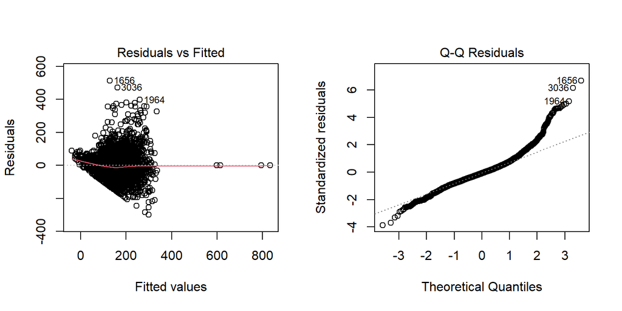

```r
par(mfrow=c(1,2))
plot(final.fit, 1)
plot(final.fit, 2)
```

**Analaysis** The final variable Age65AndOlderPct2010 has coefficent of 5.059, which indicate that counties with high percentage of elderly citizens on average have higher death rates.

The final variable WhiteNonHispanicPct2010 has a -1.070 coefficient, which means that counties with high percentage of non-whites have higher death rates. Since African Americans and Latinos make up approximately 75% of non-whites across the united states, we can surmise that COVID death rate among them are indeed higher.

The F-test in the first chunk below shows that state variables are significant controlling for other variables selected in the final fit. Summary of the final fit in the next chunk shows that some states such as SD and NJ have higher death rates than others, as indicated by the positive coefficients. A look at the Anova shows that some state variables (such as DC and RI) are insignificant in predicting the death rates.

As stated previously, we find based on our final model that counties with high percentage of elderly population have higher death rates on average. One other interesting finding is that four counties - Emporia, Galax, Gove, and Jerauld - have significantly higher death rates than other counties on average.

```r
# we test the significance of state variables using anova()

# we first fit a linear model regression without the state variables
data.nonstate <-  data.sub %>% select(nonstate_vars, "total_death_per100k")
nonstate.fit <- lm(total_death_per100k~., data.nonstate)

# then we use little anova to see the significance
anova(nonstate.fit, final.fit)
```

```
## Analysis of Variance Table
##
## Model 1: total_death_per100k ~ CountyEmporia + CountyGalax + CountyGove +
##     CountyJerauld + MedHHInc + PovertyAllAgesPct + PctEmpConstruction +
##     Age65AndOlderPct2010 + Ed5CollegePlusPct + NetMigrationRate1019 +
##     WhiteNonHispanicPct2010
## Model 2: total_death_per100k ~ StateAR + StateAZ + StateCA + StateCO +
##     StateCT + StateDC + StateDE + StateFL + StateGA + StateIA +
##     StateID + StateIL + StateIN + StateKS + StateKY + StateLA +
##     StateMA + StateMD + StateME + StateMI + StateMN + StateMO +
##     StateMS + StateMT + StateNC + StateND + StateNE + StateNH +
##     StateNJ + StateNM + StateNV + StateNY + StateOH + StateOK +
##     StateOR + StatePA + StateRI + StateSC + StateSD + StateTN +
##     StateTX + StateUT + StateVA + StateVT + StateWA + StateWI +
##     StateWV + StateWY + CountyEmporia + CountyGalax + CountyGove +
##     CountyJerauld + PctEmpConstruction + Age65AndOlderPct2010 +
##     Ed5CollegePlusPct + NetMigrationRate1019 + WhiteNonHispanicPct2010
##   Res.Df      RSS Df Sum of Sq    F Pr(>F)
## 1   3093 24364462
## 2   3047 18274218 46   6090244 22.1 <2e-16 ***
## ---
## Signif. codes:  0 '***' 0.001 '**' 0.01 '*' 0.05 '.' 0.1 ' ' 1
```

```r
summary(final.fit)
```

```
##
## Call:
## lm(formula = total_death_per100k ~ ., data = final_data)
##
## Residuals:
##    Min     1Q Median     3Q    Max
## -298.8  -44.5   -6.1   34.8  513.8
##
## Coefficients:
##                         Estimate Std. Error t value Pr(>|t|)
## (Intercept)              241.783     13.698   17.65  < 2e-16 ***
## StateAR                   -1.195     13.076   -0.09  0.92720
## StateAZ                   36.264     22.254    1.63  0.10330
## StateCA                 -106.352     14.014   -7.59  4.3e-14 ***
## StateCO                  -33.430     13.927   -2.40  0.01643 *
## StateCT                   21.838     29.237    0.75  0.45515
## StateDC                   -7.470     78.403   -0.10  0.92410
## StateDE                  -35.737     45.773   -0.78  0.43501
## StateFL                  -26.729     13.676   -1.95  0.05074 .
## StateGA                   13.720     11.315    1.21  0.22539
## StateIA                   27.940     12.623    2.21  0.02694 *
## StateID                  -62.320     15.163   -4.11  4.1e-05 ***
## StateIL                   18.472     12.549    1.47  0.14113
## StateIN                   -5.817     12.815   -0.45  0.64992
## StateKS                  -47.434     12.468   -3.80  0.00014 ***
## StateKY                  -60.163     12.225   -4.92  9.1e-07 ***
## StateLA                   41.072     13.605    3.02  0.00256 **
## StateMA                   44.169     23.184    1.91  0.05686 .
## StateMD                  -37.846     18.611   -2.03  0.04209 *
## StateME                 -112.399     21.808   -5.15  2.7e-07 ***
## StateMI                  -30.500     12.965   -2.35  0.01871 *
## StateMN                  -43.428     12.891   -3.37  0.00076 ***
## StateMO                  -55.557     12.197   -4.55  5.4e-06 ***
## StateMS                   45.347     12.804    3.54  0.00040 ***
## StateMT                    5.600     14.248    0.39  0.69431
## StateNC                  -64.991     12.275   -5.29  1.3e-07 ***
## StateND                   65.066     14.511    4.48  7.6e-06 ***
## StateNE                  -58.423     12.794   -4.57  5.2e-06 ***
## StateNH                  -68.018     26.546   -2.56  0.01045 *
## StateNJ                   59.719     19.703    3.03  0.00246 **
```

[output cut: 19 more lines]

```
## CountyEmporia            409.285     77.901    5.25  1.6e-07 ***
## CountyGalax              465.560     77.786    5.99  2.4e-09 ***
## CountyGove               685.247     77.854    8.80  < 2e-16 ***
## CountyJerauld            497.625     78.097    6.37  2.1e-10 ***
## PctEmpConstruction        -3.843      0.657   -5.85  5.4e-09 ***
## Age65AndOlderPct2010       5.059      0.430   11.78  < 2e-16 ***
## Ed5CollegePlusPct         -1.673      0.197   -8.48  < 2e-16 ***
## NetMigrationRate1019      -1.863      0.235   -7.94  2.8e-15 ***
## WhiteNonHispanicPct2010   -1.070      0.115   -9.32  < 2e-16 ***
## ---
## Signif. codes:  0 '***' 0.001 '**' 0.01 '*' 0.05 '.' 0.1 ' ' 1
##
## Residual standard error: 77.4 on 3047 degrees of freedom
## Multiple R-squared:  0.429,  Adjusted R-squared:  0.418
## F-statistic: 40.2 on 57 and 3047 DF,  p-value: <2e-16
```

```r
Anova(final.fit)
```

```
## Anova Table (Type II tests)
##
## Response: total_death_per100k
##                           Sum Sq   Df F value  Pr(>F)
## StateAR                       50    1    0.01 0.92720
## StateAZ                    15926    1    2.66 0.10330
## StateCA                   345430    1   57.60 4.3e-14 ***
## StateCO                    34558    1    5.76 0.01643 *
## StateCT                     3346    1    0.56 0.45515
## StateDC                       54    1    0.01 0.92410
## StateDE                     3656    1    0.61 0.43501
## StateFL                    22909    1    3.82 0.05074 .
## StateGA                     8818    1    1.47 0.22539
## StateIA                    29385    1    4.90 0.02694 *
## StateID                   101304    1   16.89 4.1e-05 ***
## StateIL                    12995    1    2.17 0.14113
## StateIN                     1236    1    0.21 0.64992
## StateKS                    86807    1   14.47 0.00014 ***
## StateKY                   145251    1   24.22 9.1e-07 ***
## StateLA                    54663    1    9.11 0.00256 **
## StateMA                    21768    1    3.63 0.05686 .
## StateMD                    24801    1    4.14 0.04209 *
## StateME                   159317    1   26.56 2.7e-07 ***
## StateMI                    33193    1    5.53 0.01871 *
## StateMN                    68064    1   11.35 0.00076 ***
## StateMO                   124428    1   20.75 5.4e-06 ***
## StateMS                    75227    1   12.54 0.00040 ***
## StateMT                      927    1    0.15 0.69431
## StateNC                   168120    1   28.03 1.3e-07 ***
## StateND                   120578    1   20.10 7.6e-06 ***
## StateNE                   125054    1   20.85 5.2e-06 ***
## StateNH                    39374    1    6.57 0.01045 *
## StateNJ                    55098    1    9.19 0.00246 **
## StateNM                    58509    1    9.76 0.00180 **
## StateNV                    76545    1   12.76 0.00036 ***
## StateNY                    52507    1    8.75 0.00311 **
## StateOH                    94989    1   15.84 7.1e-05 ***
## StateOK                   239879    1   40.00 2.9e-10 ***
## StateOR                   292384    1   48.75 3.6e-12 ***
## StatePA                     2477    1    0.41 0.52048
```

[output cut: 9 more lines]

```
## StateWI                    43084    1    7.18 0.00740 **
## StateWV                   135719    1   22.63 2.1e-06 ***
## StateWY                    29833    1    4.97 0.02580 *
## CountyEmporia             165552    1   27.60 1.6e-07 ***
## CountyGalax               214838    1   35.82 2.4e-09 ***
## CountyGove                464622    1   77.47 < 2e-16 ***
## CountyJerauld             243503    1   40.60 2.1e-10 ***
## PctEmpConstruction        205250    1   34.22 5.4e-09 ***
## Age65AndOlderPct2010      831789    1  138.69 < 2e-16 ***
## Ed5CollegePlusPct         430860    1   71.84 < 2e-16 ***
## NetMigrationRate1019      378103    1   63.04 2.8e-15 ***
## WhiteNonHispanicPct2010   520473    1   86.78 < 2e-16 ***
## Residuals               18274218 3047
## ---
## Signif. codes:  0 '***' 0.001 '**' 0.01 '*' 0.05 '.' 0.1 ' ' 1
```

One potentially predictive variable is the number of hospitals/health care practitioners per county. We can go further by using number of hospitals per 100k citizens of the county. We hypothesize that it is inversely correlated with death rates. Having information on how much immediate treatment is available compared to the size of population may significantly improve the model.